# hw7

Charles Yang

10/24/2021

```r
# 1b
x1 = -2
x2 = 5
x3 = -1
x4 = 10
x5 = 5

for (B0 in -15:0) {
    B1 = 12
    print(paste0("B0 = ", B0, ", B1 = ", B1, ", l = ", 1/(1+exp(B0 + B1*x1)) * exp(B0 + B1*x2)/(1+exp(B0 + B1*x2)) + 1/(1+exp(B0 + B1*x3)) * exp(B0 + B1*x4)/(1+exp(B0 + B1*x4)) * exp(B0 + B1*x5)/(1+exp(B0 + B1*x5))))
}

B0 = -15
B1 = 12
exp(B0 + B1*x5)/(1+exp(B0 + B1*x5))
```

[output not shown]

```r
# 1h
n = 16
x1 = c(sample(1:8, n/2), sample(9:16, n/2))
x2 = c(sample(1:8, n/2), sample(9:16, n/2))

sketchyData <- data.frame(
  x1 = x1,
  x2 = x2
)

sketchyData = cbind(sketchyData, sketchyData[1] > 8)
names(sketchyData)[3] <- "Y"

sketchyFit = glm(Y~., data=sketchyData, family='binomial')
sketchyProb = predict(sketchyFit, sketchyData, type='response')
sketchyProb
```

```
##            1            2            3            4            5            6
## 2.220446e-16 2.220446e-16 3.805190e-12 1.152443e-10 2.220446e-16 2.220446e-16
##            7            8            9           10           11           12
## 2.220446e-16 2.220446e-16 1.000000e+00 1.000000e+00 1.000000e+00 1.000000e+00
##           13           14           15           16
## 1.000000e+00 1.000000e+00 1.000000e+00 1.000000e+00
```

```r
sketchyPred = rep(FALSE, n)
sketchyPred[sketchyProb > 0.5] = TRUE
sketchyTable = table(sketchyPred, sketchyData[,3])
sketchyTable
```

```
##
## sketchyPred FALSE TRUE
##       FALSE     8    0
##       TRUE      0    8
```

```r
1 - sum(diag(sketchyTable)) / sum(sketchyTable)
```

```
## [1] 0
```

```r
# 1i
sketchy.lda.fit = lda(Y~., data=sketchyData)

sketchy.lda.pred = predict(sketchy.lda.fit, sketchyData)

table(sketchy.lda.pred$class, sketchyData$Y)
```

```
##
##         FALSE TRUE
##   FALSE     8    0
##   TRUE      0    8
```

```r
mean(sketchy.lda.pred$class != sketchyData$Y)
```

```
## [1] 0
```

```r
sketchy.qda.fit = qda(Y~., data=sketchyData)
sketchy.qda.pred = predict(sketchy.qda.fit, data=sketchyData)

table(sketchy.qda.pred$class, sketchyData$Y)
```

```
##
##         FALSE TRUE
##   FALSE     8    0
##   TRUE      0    8
```

```r
mean(sketchy.qda.pred$class != sketchyData$Y)
```

```
## [1] 0
```

1. Concept Review

a. (32 + 25) / 218 = 0.2615 overall misclassification rate. False negatives would be dangerous, because someone who is sick could go without treatment. We can bias the false positive rate by dereasing the probability threshold to classify someone as sick. This would increase overall misclassification, but would decrease false negatives.

b. P(Y1 = red | Xi < 5) = 2/5, P(Y1 = blue | Xi >= 5) = 3/5  
First, I calculated likelihood using the provided formula. Through numerical analysis, I found that large negative values of B0 and large positive values of B1 seem to maximize likelihood, which asymtotically approaches +2. Additionally, when x = 5, these beta values accurately predict that an observation with x = 5 will be blue with probability 1 (per the given data). This is perfect separation.

c. Because there are so many predictors relative to observations, all observations will be relatively far away from eachother. KNN is unlikely to perform well in this setting.

d.  
i. LDA may be better. LDA requires predictors to be roughly normally distributed, and we know weight and height is roughly normally distributed in humans. Additionally, There are less likely to be gross outliers.  
ii. Use logistic regression. Income and Hours worked will certainly contain gross outliers, so LDA may not perform as well.  
iii. Use KNN because it is capabable of drawing incredily complicated and non-linear decision boundaries. This is due to it's flexibility.

e. QDA is is more flexible than QDA. If the true boundry is linear and the variances are constant, then QDA will overfit the data. As a result, it won't perform as well on new data compared to LDA.

f. QDA will overfit the training set and minimize the misclassification rate on the training data. QDA will perform better because it fits closer to the training data.

g. False. I refer to my answer in e.

h. Logistic regression cannot converge because the coefficients of x1 and x2 do not exist. Likelihood can't really be maximized here.

i. The misclassification rate for both LDA and QDA is 0. This could be meaningful, if two real life categories are actually complete different in every measure. But, it could also be entirely useless depending on the application, especially if n is small.

```r
# 2a
set.seed(1)
x1 = rnorm(1000) # create 3 predictors
x2 = rnorm(1000)
x3 = rnorm(1000)
#true population parameters
B0 = 1
B1 = 2
B2 = 3
B3 = 2

pr = exp(B0 + B1*x1 + B2*x2 + B3*x3) / (1 + exp(B0 + B1*x1 + B2*x2 + B3*x3))

y = as.factor(rbinom(1000, 1, pr))

df = data.frame(y=y, x1=x1, x2=x2, x3=x3)

train = sample(1:nrow(df),nrow(df)/2, replace=FALSE)
test = (-train)
```

```r
# 2b
print("Logistic")
```

```
## [1] "Logistic"
```

```r
glm.fit = glm(y~., data=df, subset=train, family='binomial')
glm.prob = predict(glm.fit, df[test, ], type='response')

glm.pred = rep('No', length(test))
glm.pred[glm.prob > 0.5] ='Yes'
tab = table(glm.pred, df[test, ]$y)
tab
```

```
##
## glm.pred   0   1
##      No  177  27
##      Yes  28 268
```

```r
1 - sum(diag(tab)) / sum(tab)
```

```
## [1] 0.11
```

```r
# 2c
print("LDA")
```

```
## [1] "LDA"
```

```r
lda.fit = lda(y~., data=df, subset=train)

lda.pred = predict(lda.fit, df[test, ])

table(lda.pred$class, df[test, ]$y)
```

```
##
##       0   1
##   0 174  25
##   1  31 270
```

```r
mean(lda.pred$class != df[test, ]$y)
```

```
## [1] 0.112
```

```r
# 2d
print("Default Naive Bayes")
```

```
## [1] "Default Naive Bayes"
```

```r
nb.fit = naiveBayes(y~., data=df, subset = train)

nb.class = predict(nb.fit, df[test, ])

table(nb.class, df[test, ]$y)
```

```
##
## nb.class   0   1
##        0 169  22
##        1  36 273
```

```r
mean(nb.class != df[test, ]$y)
```

```
## [1] 0.116
```

```r
# 2d
print("Naive Bayes with Kernel")
```

```
## [1] "Naive Bayes with Kernel"
```

```r
nb.fit2 = NaiveBayes(y~., data=df, subset=train, usekernel = TRUE)

nb2.class = predict(nb.fit2, df[test, ])$class

table(nb2.class, df[test, ]$y)
```

```
##
## nb2.class   0   1
##         0 168  24
##         1  37 271
```

```r
mean(nb2.class != df[test, ]$y)
```

```
## [1] 0.122
```

2. Practicing Data Simpulations

a. See code above.

b. Logistic regression gives a misclassiciation rate of 0.11.

c. LDA gives a misclassiciation rate of 0.112.

d. Naive Bayes gives a misclassiciation rate of 0.116 and the Kernel version gives 0.122.

e. Logistic regression had the highest accuracy, followed by LDA, Naive Bayes, and Naive Bayes with Kernel Density Estimation.

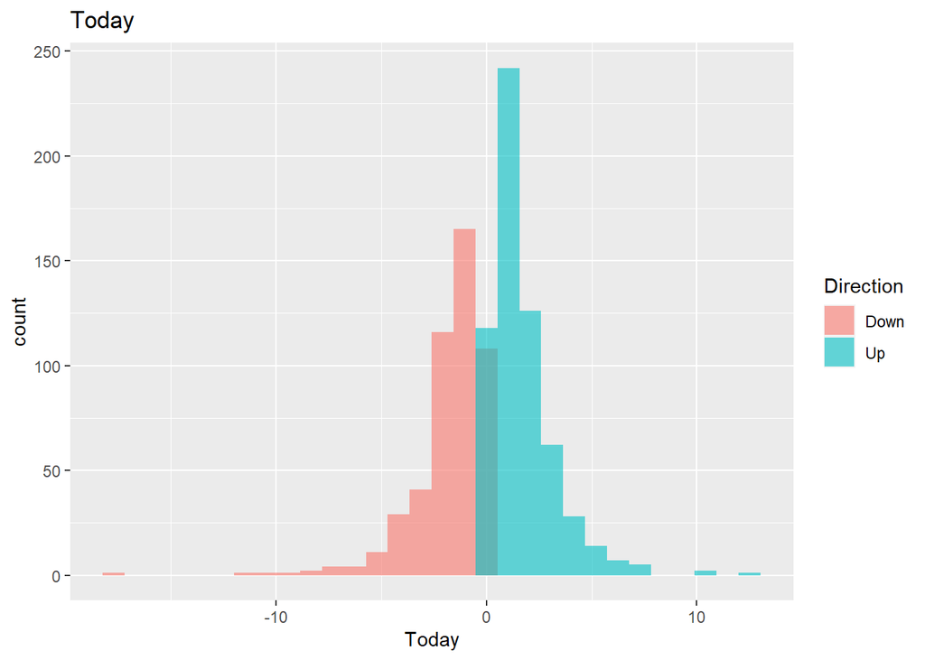

```r
# 3a
ggplot(data=Weekly, aes(x=Today, fill=Direction)) +
  geom_histogram(alpha=0.6, position='identity') +
  ggtitle("Today")
```

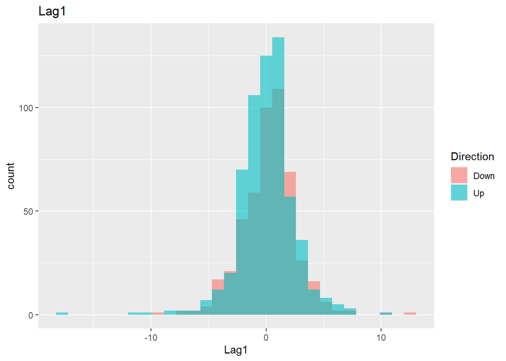

```r
ggplot(data=Weekly, aes(x=Lag1, fill=Direction)) +
  geom_histogram(alpha=0.6, position='identity') +
  ggtitle("Lag1")
```

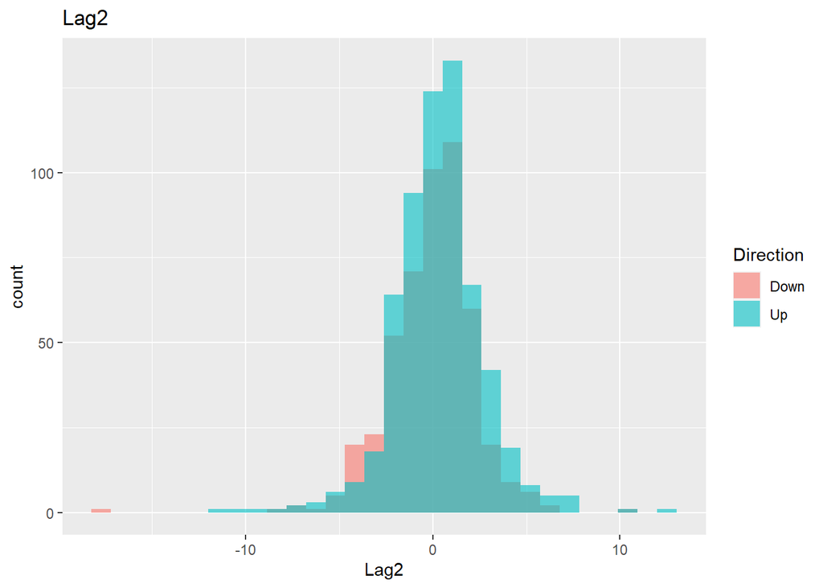

```r
ggplot(data=Weekly, aes(x=Lag2, fill=Direction)) +
  geom_histogram(alpha=0.6, position='identity') +
  ggtitle("Lag2")
```

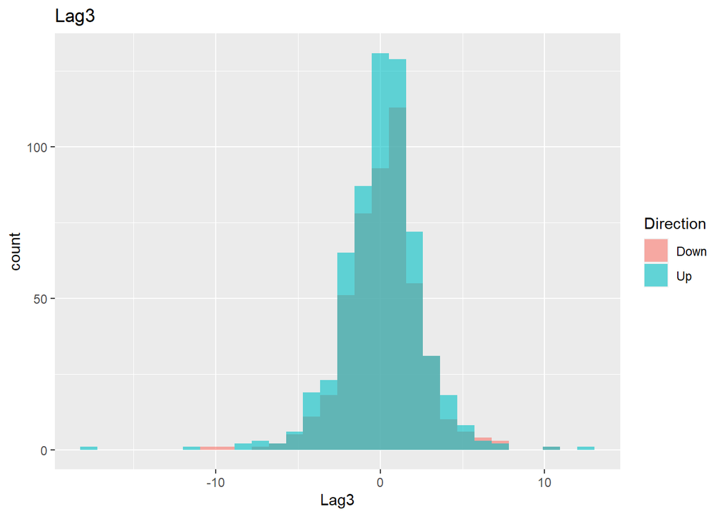

```r
ggplot(data=Weekly, aes(x=Lag3, fill=Direction)) +
  geom_histogram(alpha=0.6, position='identity') +
  ggtitle("Lag3")
```

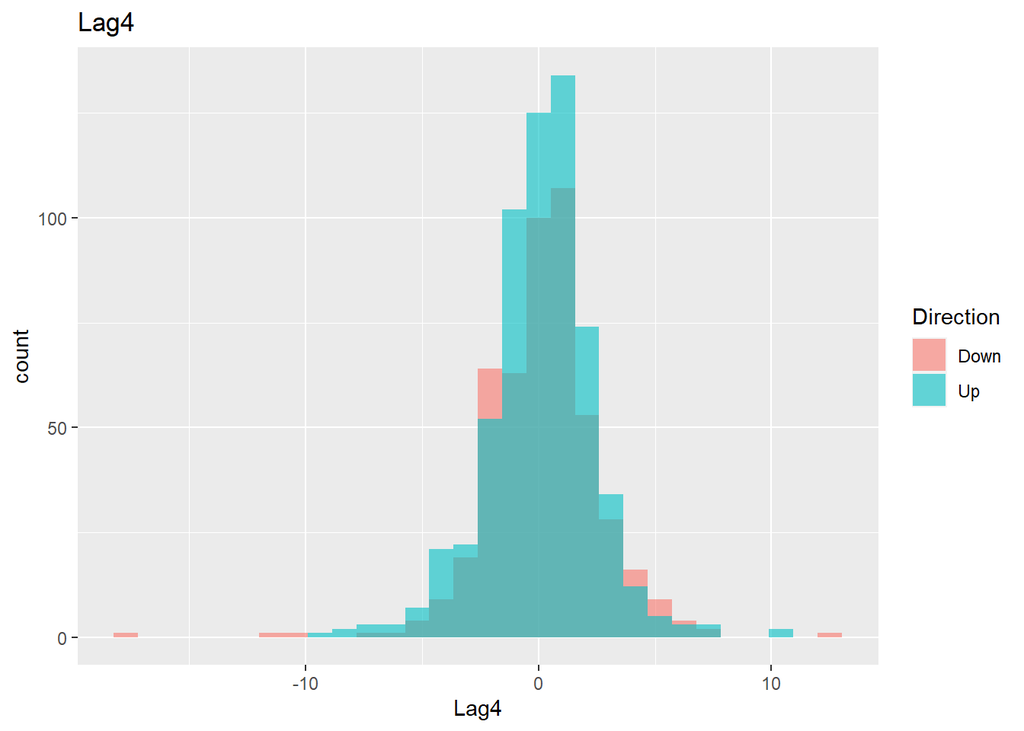

```r
ggplot(data=Weekly, aes(x=Lag4, fill=Direction)) +
  geom_histogram(alpha=0.6, position='identity') +
  ggtitle("Lag4")
```

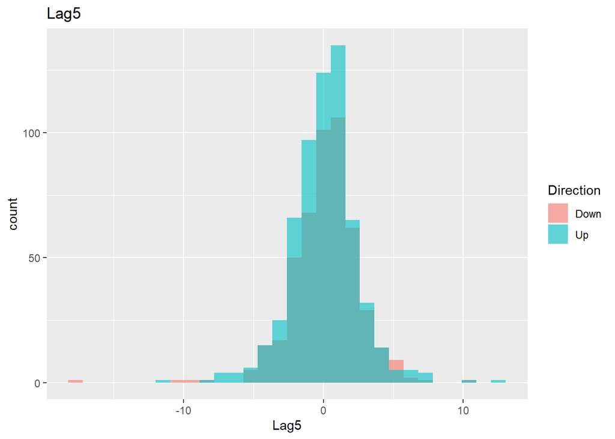

```r
ggplot(data=Weekly, aes(x=Lag5, fill=Direction)) +
  geom_histogram(alpha=0.6, position='identity') +
  ggtitle("Lag5")
```

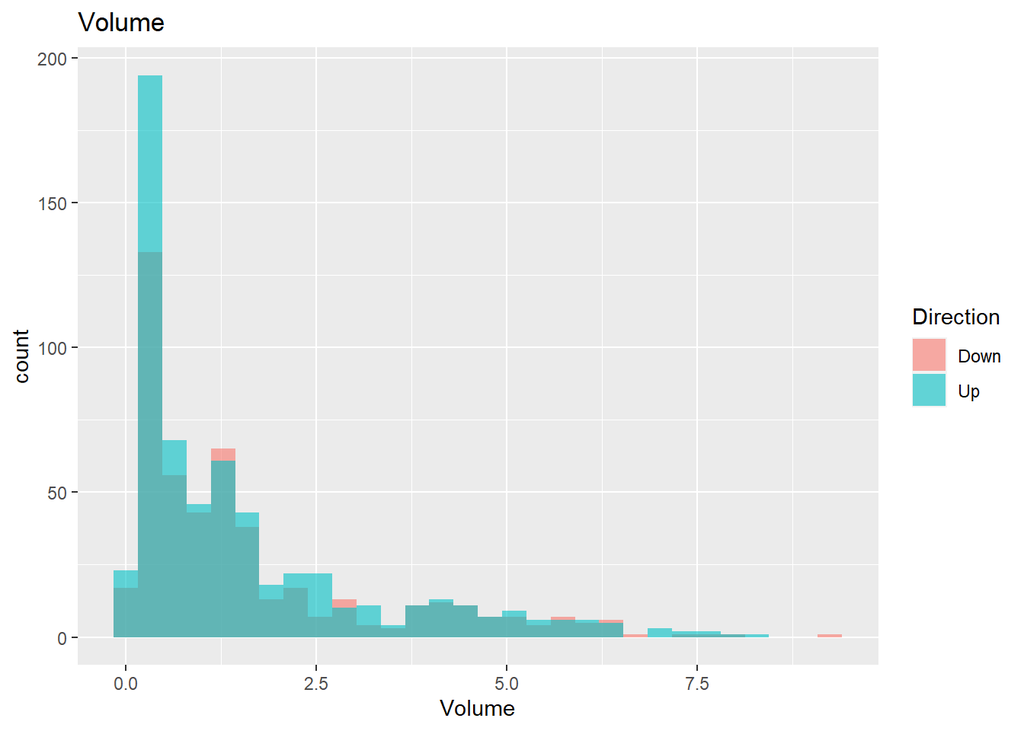

```r
ggplot(data=Weekly, aes(x=Volume, fill=Direction)) +
  geom_histogram(alpha=0.6, position='identity') +
  ggtitle("Volume")
```

```r
get_lower_tri<-function(cormat){
    cormat[upper.tri(cormat)] <- NA
    return(cormat)
}
```

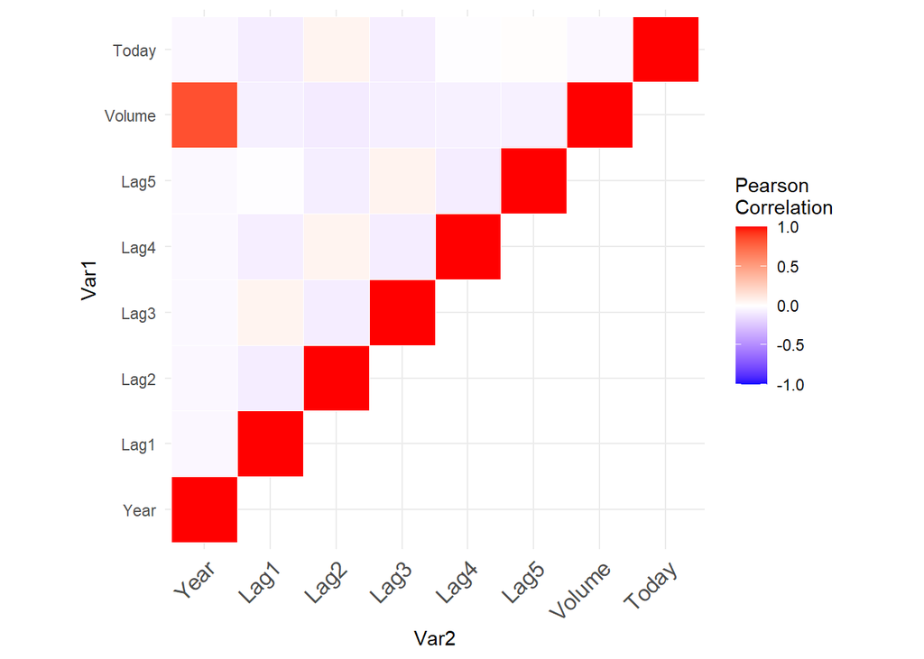

```r
# 3a
upper_tri <- get_lower_tri(cor(Weekly[,-9]))
melted_cormat <- melt(upper_tri, na.rm = TRUE)

ggplot(data = melted_cormat, aes(Var2, Var1, fill = value))+
 geom_tile(color = "white")+
 scale_fill_gradient2(low = "blue", high = "red", mid = "white",
   midpoint = 0, limit = c(-1,1), space = "Lab",
   name="Pearson\nCorrelation") +
  theme_minimal()+
 theme(axis.text.x = element_text(angle = 45, vjust = 1,
    size = 12, hjust = 1))+
 coord_fixed()
```

```r
trainIndex = (Weekly$Year<2008)
trainWeekly = Weekly[trainIndex,]
testWeekly = Weekly[!trainIndex,]
nrow(testWeekly)
```

[output not shown]

```r
# 3b
glm.fit = glm(Direction~Lag2, data=trainWeekly, family='binomial')
glm.prob = predict(glm.fit, testWeekly, type='response')

glm.pred = rep('No', nrow(testWeekly))
glm.pred[glm.prob > 0.5] ='Yes'

print("Logistic")
```

```
## [1] "Logistic"
```

```r
tab = table(glm.pred, testWeekly$Direction)
tab
```

```
##
## glm.pred Down Up
##      No     7  5
##      Yes   65 79
```

```r
sum(diag(tab)) / sum(tab)
```

```
## [1] 0.5512821
```

```r
# 3c
lda.fit = lda(Direction~Lag2, data=trainWeekly)

lda.pred = predict(lda.fit, testWeekly)

print("LDA")
```

```
## [1] "LDA"
```

```r
table(lda.pred$class, testWeekly$Direction)
```

```
##
##        Down Up
##   Down    6  5
##   Up     66 79
```

```r
mean(lda.pred$class == testWeekly$Direction)
```

```
## [1] 0.5448718
```

```r
# 3d
qda.fit = qda(Direction~Lag2, data=trainWeekly)

qda.pred = predict(qda.fit, testWeekly)

print("QDA")
```

```
## [1] "QDA"
```

```r
table(qda.pred$class, testWeekly$Direction)
```

```
##
##        Down Up
##   Down    0  0
##   Up     72 84
```

```r
mean(qda.pred$class == testWeekly$Direction)
```

```
## [1] 0.5384615
```

```r
# 3e
K = c(3, 5, 7, 9, 11)
standardizedX = scale(trainWeekly[, -9]$Lag2)
flds <- createFolds(trainWeekly$Direction, k = 5, list = TRUE, returnTrain = FALSE)

cvMisclassification = matrix(NA, 5, 5)

for(j in 1:5){
  k = K[j]
  for(i in 1:5){
    test_index = flds[[i]]

    testX = as.matrix(standardizedX[test_index])
    trainX = as.matrix(standardizedX[-test_index])

    testY = trainWeekly$Direction[test_index]
    trainY = trainWeekly$Direction[-test_index]

    knn.pred = knn(trainX, testX, trainY, k=k)
    cvMisclassification[i,j] = mean(testY != knn.pred)
  }
}
apply(cvMisclassification,2,mean)
```

```
## [1] 0.5025939 0.4811345 0.4822039 0.4747630 0.4683228
```

```r
train.X = standardizedX
train.Y = Weekly$Direction[trainIndex]
knn.pred = knn(train.X, scale(testWeekly[,-9]$Lag2), train.Y, k=9)

print("KNN")
```

```
## [1] "KNN"
```

```r
table(knn.pred, testWeekly$Direction)
```

```
##
## knn.pred Down Up
##     Down   25 32
##     Up     47 52
```

```r
mean(testWeekly$Direction == knn.pred)
```

```
## [1] 0.4935897
```

```r
# 3f
nb.fit = naiveBayes(Direction~Lag2, data=trainWeekly)

nb.class = predict(nb.fit, testWeekly)

print("Naive Bayes")
```

```
## [1] "Naive Bayes"
```

```r
table(nb.class, testWeekly$Direction)
```

```
##
## nb.class Down Up
##     Down    0  0
##     Up     72 84
```

```r
mean(testWeekly$Direction == nb.class)
```

```
## [1] 0.5384615
```

```r
# 3f
nb.fit2 = NaiveBayes(Direction~Lag2, data=trainWeekly, usekernel = TRUE)

nb2.class = predict(nb.fit2, testWeekly)$class

print("Naive Bayes with Kernel")
```

```
## [1] "Naive Bayes with Kernel"
```

```r
table(nb2.class, testWeekly$Direction)
```

```
##
## nb2.class Down Up
##      Down   15  8
##      Up     57 76
```

```r
mean(nb2.class == testWeekly$Direction)
```

```
## [1] 0.5833333
```

```r
# 3h, Lag1
glm.fit = glm(Direction~Lag1, data=trainWeekly, family='binomial')
glm.prob = predict(glm.fit, testWeekly, type='response')

glm.pred = rep('No', nrow(testWeekly))
glm.pred[glm.prob > 0.5] ='Yes'

print("Logistic")
```

```
## [1] "Logistic"
```

```r
tab = table(glm.pred, testWeekly$Direction)
tab
```

```
##
## glm.pred Down Up
##      No     7  3
##      Yes   65 81
```

```r
sum(diag(tab)) / sum(tab)
```

```
## [1] 0.5641026
```

```r
lda.fit = lda(Direction~Lag1, data=trainWeekly)

lda.pred = predict(lda.fit, testWeekly)

print("LDA")
```

```
## [1] "LDA"
```

```r
table(lda.pred$class, testWeekly$Direction)
```

```
##
##        Down Up
##   Down    6  3
##   Up     66 81
```

```r
mean(lda.pred$class == testWeekly$Direction)
```

```
## [1] 0.5576923
```

```r
qda.fit = qda(Direction~Lag1, data=trainWeekly)

qda.pred = predict(qda.fit, testWeekly)

print("QDA")
```

```
## [1] "QDA"
```

```r
table(qda.pred$class, testWeekly$Direction)
```

```
##
##        Down Up
##   Down    0  0
##   Up     72 84
```

```r
mean(qda.pred$class == testWeekly$Direction)
```

```
## [1] 0.5384615
```

```r
K = c(3, 5, 7, 9, 11, 13, 15, 17, 19, 21)
standardizedX = scale(trainWeekly[, -9]$Lag1)
flds <- createFolds(trainWeekly$Direction, k = 5, list = TRUE, returnTrain = FALSE)

cvMisclassification = matrix(NA, 5, length(K))

for(j in 1:length(K)){
  k = K[j]
  for(i in 1:5){
    test_index = flds[[i]]

    testX = as.matrix(standardizedX[test_index])
    trainX = as.matrix(standardizedX[-test_index])

    testY = trainWeekly$Direction[test_index]
    trainY = trainWeekly$Direction[-test_index]

    knn.pred = knn(trainX, testX, trainY, k=k)
    cvMisclassification[i,j] = mean(testY != knn.pred)
  }
}
apply(cvMisclassification,2,mean)
```

```
##  [1] 0.4930021 0.4961877 0.4769076 0.4790524 0.4726640 0.4554885 0.4758496
##  [8] 0.4726640 0.4501466 0.4490829
```

```r
train.X = standardizedX
train.Y = Weekly$Direction[trainIndex]
knn.pred = knn(train.X, scale(testWeekly[,-9]$Lag1), train.Y, k=11)

print("KNN")
```

```
## [1] "KNN"
```

```r
table(knn.pred, testWeekly$Direction)
```

```
##
## knn.pred Down Up
##     Down   19 36
##     Up     53 48
```

```r
mean(testWeekly$Direction == knn.pred)
```

```
## [1] 0.4294872
```

```r
nb.fit = naiveBayes(Direction~Lag1, data=trainWeekly)

nb.class = predict(nb.fit, testWeekly)

print("Naive Bayes")
```

```
## [1] "Naive Bayes"
```

```r
table(nb.class, testWeekly$Direction)
```

```
##
## nb.class Down Up
##     Down    0  0
##     Up     72 84
```

```r
mean(testWeekly$Direction == nb.class)
```

```
## [1] 0.5384615
```

```r
nb.fit2 = NaiveBayes(Direction~Lag1, data=trainWeekly, usekernel = TRUE)

nb2.class = predict(nb.fit2, testWeekly)$class

print("Naive Bayes with Kernel")
```

```
## [1] "Naive Bayes with Kernel"
```

```r
table(nb2.class, testWeekly$Direction)
```

```
##
## nb2.class Down Up
##      Down   17 22
##      Up     55 62
```

```r
mean(nb2.class == testWeekly$Direction)
```

```
## [1] 0.5064103
```

```r
K = c(3, 5, 7, 9, 11, 13, 15, 17, 19, 21)
standardizedX = scale(trainWeekly[, -9])
flds = createFolds(trainWeekly$Direction, k = 5, list = TRUE, returnTrain = FALSE)

cvMisclassification = matrix(NA, 5, length(K))

for(j in 1:length(K)){
  k = K[j]
  for(i in 1:5){
    test_index = flds[[i]]

    testX = as.matrix(standardizedX[test_index,])
    trainX = as.matrix(standardizedX[-test_index,])

    testY = trainWeekly$Direction[test_index]
    trainY = trainWeekly$Direction[-test_index]

    knn.pred = knn(trainX, testX, trainY, k=k)
    cvMisclassification[i,j] = mean(testY != knn.pred)
  }
}
apply(cvMisclassification,2,mean)
```

```
##  [1] 0.11355299 0.10924041 0.10283480 0.09749871 0.10608936 0.10180553
##  [7] 0.09751596 0.09858548 0.09858548 0.10179978
```

```r
train.X = standardizedX
train.Y = Weekly$Direction[trainIndex]
knn.pred = knn(train.X, scale(testWeekly[,-9]), train.Y, k=9)

print("KNN")
```

```
## [1] "KNN"
```

```r
table(knn.pred, testWeekly$Direction)
```

```
##
## knn.pred Down Up
##     Down   57  2
##     Up     15 82
```

```r
mean(testWeekly$Direction == knn.pred)
```

```
## [1] 0.8910256
```

3. Weekly Data

a. From the Histograms, we can see that there are very few differences in the histograms for all predictors except for Lag1. For some reason, Volume is highly correlated with Year.

b. 0.5513 classification rate for Logsitic Regression

c. 0.5449 classification rate for LDA

d. 0.5385 classification rate for QDA

f. 0.5384 classification rate for Naive Bayes, 0.5833 with Kernel

h. Tried same process as 3b-g but with Lag1, since Lag1 seems different by direction.  
Logisticc regression outperformed all others using Lag1 with a classification rate of 0.5641 See output for confusion matrix.  
Tried KNN on all predictors for fun. Got an incredible classification rate of 0.8910. This is clearly the best of all models I've created.

```r
spam = read.csv('spambase.data', header = FALSE)
spam$V58 = as_factor(spam$V58)
```

```r
# 4a ... why won't length work? I have to use sum?
sum(spam$V58==1)/nrow(spam)
```

```
## [1] 0.3940448
```

```r
sum(spam$V58==0)/nrow(spam)
```

```
## [1] 0.6059552
```

```r
# 4b
trainIndex = createDataPartition(spam$V58, p = .60, list = FALSE)
train = spam[trainIndex,]
test = spam[-trainIndex,]
print("Train spam proportion")
```

```
## [1] "Train spam proportion"
```

```r
sum(train$V58==1)/nrow(train)
```

```
## [1] 0.3940601
```

```r
print("Test spam proportion")
```

```
## [1] "Test spam proportion"
```

```r
sum(test$V58==1)/nrow(test)
```

```
## [1] 0.3940217
```

```r
# 4c+d
glm.fit = glm(V58~., data=train, family='binomial')
glm.prob = predict(glm.fit, test, type='response')

print("First ten probabilities:")
```

```
## [1] "First ten probabilities:"
```

```r
head(glm.prob, 10)
```

```
##         2         7         9        11        16        17        19        23
## 0.9900249 0.8221729 0.9999255 0.6692061 0.9823133 0.5470032 0.6730001 0.9758264
##        25        40
## 0.2946519 0.6832096
```

```r
glm.pred = rep(0, nrow(test))
glm.pred[glm.prob > 0.5] =1

tab = table(glm.pred, test$V58)
tab
```

```
##
## glm.pred    0    1
##        0 1069   88
##        1   46  637
```

```r
1 - sum(diag(tab)) / sum(tab)
```

```
## [1] 0.07282609
```

```r
46/sum(tab) # False positive
```

```
## [1] 0.025
```

```r
88/sum(tab) # False negative
```

```
## [1] 0.04782609
```

```r
# 4f
lda.fit = lda(V58~., data=train)

lda.pred = predict(lda.fit, test)

print("LDA")
```

```
## [1] "LDA"
```

```r
tab = table(lda.pred$class, test$V58)
tab
```

```
##
##        0    1
##   0 1070  167
##   1   45  558
```

```r
mean(lda.pred$class == test$V58)
```

```
## [1] 0.8847826
```

```r
tab[2] / nrow(test)
```

```
## [1] 0.02445652
```

```r
qda.fit = qda(V58~., data=train)

qda.pred = predict(qda.fit, test)

print("QDA")
```

```
## [1] "QDA"
```

```r
tab = table(qda.pred$class, test$V58)
tab
```

```
##
##       0   1
##   0 859  40
##   1 256 685
```

```r
mean(qda.pred$class == test$V58)
```

```
## [1] 0.8391304
```

```r
tab[2] / nrow(test)
```

```
## [1] 0.1391304
```

```r
K = c(3, 5, 7, 9, 11, 13, 15, 17, 19, 21)
standardizedX = scale(train[, -58])
flds <- createFolds(train$V58, k = 5, list = TRUE, returnTrain = FALSE)

cvMisclassification = matrix(NA, 5, length(K))

for(j in 1:length(K)){
  k = K[j]
  for(i in 1:5){
    test_index = flds[[i]]

    testX = as.matrix(standardizedX[test_index, ])
    trainX = as.matrix(standardizedX[-test_index, ])

    testY = train$V58[test_index]
    trainY = train$V58[-test_index]

    knn.pred = knn(trainX, testX, trainY, k=k)
    cvMisclassification[i,j] = mean(testY != knn.pred)
  }
}
apply(cvMisclassification,2,mean)
```

```
##  [1] 0.09307873 0.09597466 0.09778823 0.09922831 0.10140616 0.10539496
##  [7] 0.10865518 0.10756494 0.10720524 0.11010248
```

```r
train.X = standardizedX
train.Y = train$V58
knn.pred = knn(train.X, scale(test[,-58]), train.Y, k=5)

print("KNN")
```

```
## [1] "KNN"
```

```r
tab = table(knn.pred, test$V58)
tab
```

```
##
## knn.pred    0    1
##        0 1040  115
##        1   75  610
```

```r
mean(test$V58 == knn.pred)
```

```
## [1] 0.8967391
```

```r
tab[2] / nrow(test)
```

```
## [1] 0.04076087
```

```r
nb.fit = naiveBayes(V58~., data=train)

nb.class = predict(nb.fit, test)

print("Naive Bayes")
```

```
## [1] "Naive Bayes"
```

```r
tab = table(nb.class, test$V58)
tab
```

```
##
## nb.class   0   1
##        0 656  46
##        1 459 679
```

```r
mean(test$V58 == nb.class)
```

```
## [1] 0.7255435
```

```r
tab[2] / nrow(test)
```

```
## [1] 0.2494565
```

```r
nb.fit2 = NaiveBayes(V58~., data=train, usekernel = TRUE)

nb2.class = predict(nb.fit2, test)$class

print("Naive Bayes with Kernel")
```

```
## [1] "Naive Bayes with Kernel"
```

```r
tab = table(nb2.class, test$V58)
tab
```

```
##
## nb2.class   0   1
##         0 300   4
##         1 815 721
```

```r
mean(nb2.class == test$V58)
```

```
## [1] 0.5548913
```

```r
tab[2] / nrow(test)
```

```
## [1] 0.4429348
```

4. Email Spam

a. Proportion of emails that are spam is 0.3940.

b. Train spam proportion: 0.3940601  
Test spam proportion: 0.3940217

c. See output above.

d. We have an overall misclassification rate of 0.0728. 0.0478 of this is false negative, that is, it was spam but not flagged. 0.025 was false positive.

e. Reporting a meaningful email as spam is the most critical. We don't want to hide emails we need to read. It's happened to me recently and it's obnoxious. We can increase the threshhold required to classify an email as spam to reduce this false positive rate.

f. See output.